# Goal

Identify B cell subsets using known markers to extract cell barcodes. The barcodes will be used to access the related immunoglobulins sequences in the 5’ sequencing dataset.

# Load and process the all CD19 run

```r
# Load libraries
library(ggplot2)
library(cowplot)
library(Matrix)
library(dplyr)
library(Seurat)
library(plotly) #to generate interactive graph
library(data.table) #to transpose the data frame
```

Run the [Seurat pipeline](https://satijalab.org/seurat/v3.1/pbmc3k_tutorial.html).

## Load the Seurat object

```r
# Load the all CD19 dataset
cd19.data <- Read10X(data.dir = "Data/Sample1_CD19+_totalBcells/filtered_gene_bc_matrices/GRCh38/")
# Initialize the Seurat object with the raw (non-normalized data).
cd19 <- CreateSeuratObject(counts = cd19.data, project = "CD19", min.cells = 3, min.features = 200)
cd19
```

```
## An object of class Seurat
## 15294 features across 4178 samples within 1 assay
## Active assay: RNA (15294 features)
```

## Standard pre-processing workflow

```r
cd19[["percent.mt"]] <- PercentageFeatureSet(object = cd19, pattern = "^MT-")

#We filter cells that have unique feature counts over 2,500 or less than 200
#We filter cells that have >5% mitochondrial counts

cd19 <- subset(x = cd19, subset = nFeature_RNA > 200 & nFeature_RNA < 2500 & percent.mt < 5)
```

## Normalizing the data

```r
cd19 <- NormalizeData(object = cd19, normalization.method = "LogNormalize", scale.factor = 1e4)
```

```r
cd19 <- FindVariableFeatures(cd19)
```

## Identification of highly variable features (feature selection)

```r
cd19 <- FindVariableFeatures(object = cd19,selection.method = 'vst', nfeatures = 2000)
```

## Scaling the data

```r
# Next, we apply a linear transformation ('scaling') that is a standard pre-processing step prior to dimensional reduction techniques like PCA. The `ScaleData` function:
#
# * Shifts the expression of each gene, so that the mean expression across cells is 0
# * Scales the expression of each gene, so that the variance across cells is 1
#     + This step gives equal weight in downstream analyses, so that highly-expressed genes do not dominate
# * The results of this are stored in `pbmc[["RNA"]]@scale.data`

all.genes <- rownames(x = cd19)
cd19 <- ScaleData(object = cd19, features = all.genes)
```

## Perform linear dimensional reduction

```r
cd19 <- RunPCA(cd19, verbose = FALSE)
```

## Cluster the cells

```r
cd19 <- FindNeighbors(object = cd19, dims = 1:10)
cd19 <- FindClusters(object = cd19, resolution = 0.5)
```

```
## Modularity Optimizer version 1.3.0 by Ludo Waltman and Nees Jan van Eck
##
## Number of nodes: 1920
## Number of edges: 63402
##
## Running Louvain algorithm...
## Maximum modularity in 10 random starts: 0.8022
## Number of communities: 7
## Elapsed time: 0 seconds
```

## Run non-linear dimensional reduction (UMAP/tSNE)

```r
cd19 <- RunUMAP(object = cd19, dims = 1:10)
```

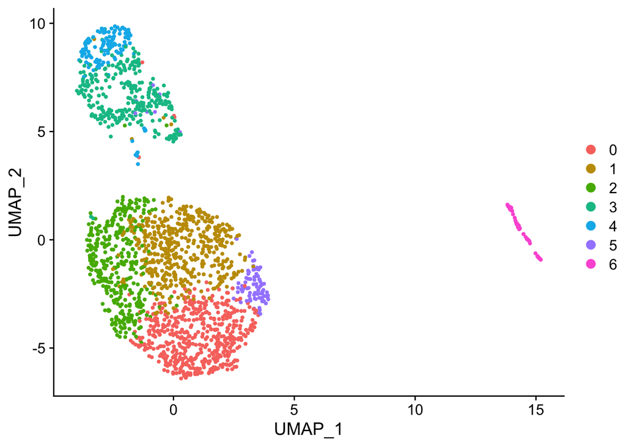

````r
#```{r fig.height=5, fig.width=7}
dimplot <- DimPlot(object = cd19, reduction = 'umap')
plot(dimplot)
````

```r
#ggplotly(dimplot)

pdf("Output/dimplot.pdf")
plot(dimplot)
dev.off()
```

# Locate subsets

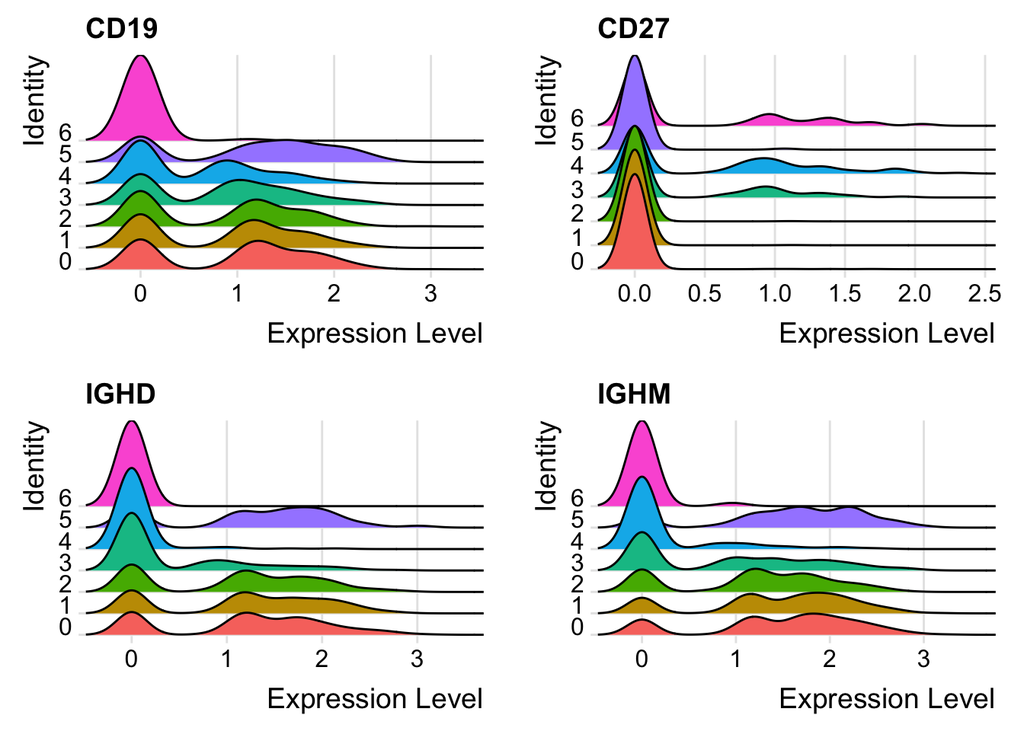

````r
#```{r fig.height=5, fig.width=7}
features <- c("CD19", "CD27", "IGHD", "IGHM")
RidgePlot(cd19, features = features, ncol = 2)
````

Cluster 3 seems to express CD19 CD27 IGHD and IGHM: Marginal Zone (MZ) B cells could be included in the cluster

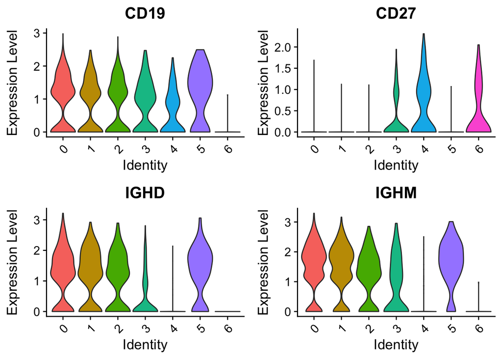

```r
vlnplot <- VlnPlot(cd19, features = features, pt.size = 0, ncol=2)
plot(vlnplot)
```

```r
pdf("Output/violin_plot.pdf")
plot(vlnplot)
dev.off()
```

This seems to confirm that at least part of the cluster 3 correspond to the MZ pop

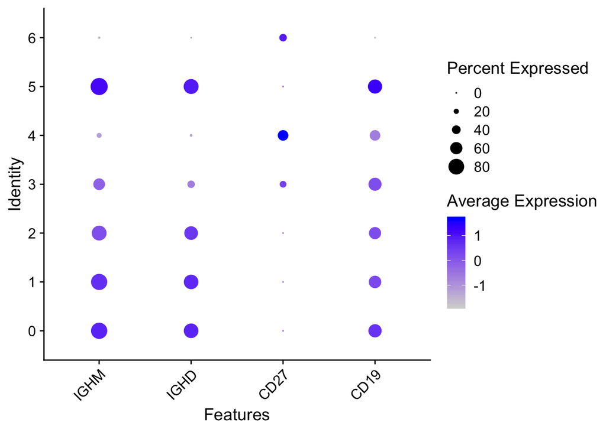

```r
#https://satijalab.org/seurat/v3.1/visualization_vignette.html
DotPlot(cd19, features = features) + RotatedAxis()
```

MZ are potentially located in cluster 3 but are a minority of the cluter.

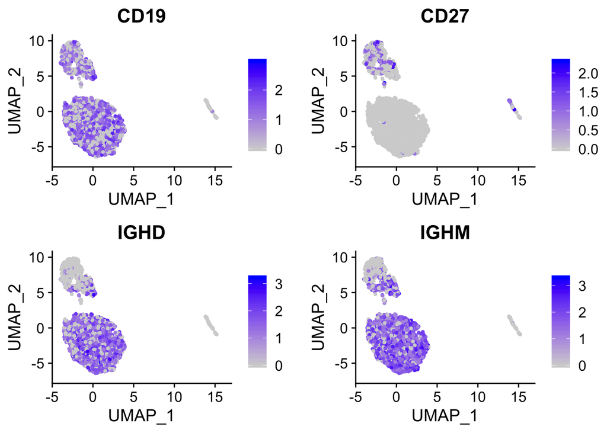

```r
FeaturePlot <- FeaturePlot(cd19, features = features)
plot(FeaturePlot)
```

```r
pdf("Output/FeaturePlot.pdf")
plot(FeaturePlot)
dev.off()
```

## Identify markers for all subsets

[Introduction to Single-cell RNA-seq](https://hbctraining.github.io/scRNA-seq/lessons/09_merged_SC_marker_identification.html) [All lessons](https://github.com/hbctraining/scRNA-seq/tree/master/lessons)

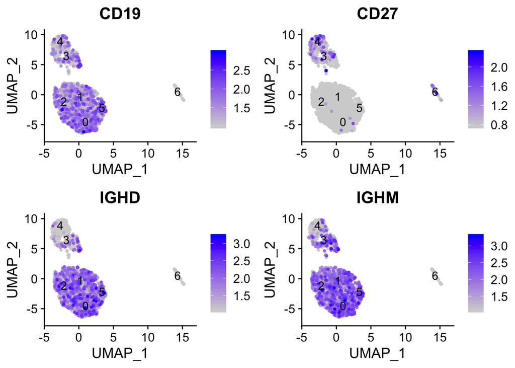

```r
FeaturePlot(object = cd19,
                        features = features,
                         sort.cell = TRUE,
                         min.cutoff = 'q10',
                         label = TRUE)
```

https://satijalab.org/seurat/v3.1/visualization_vignette.html

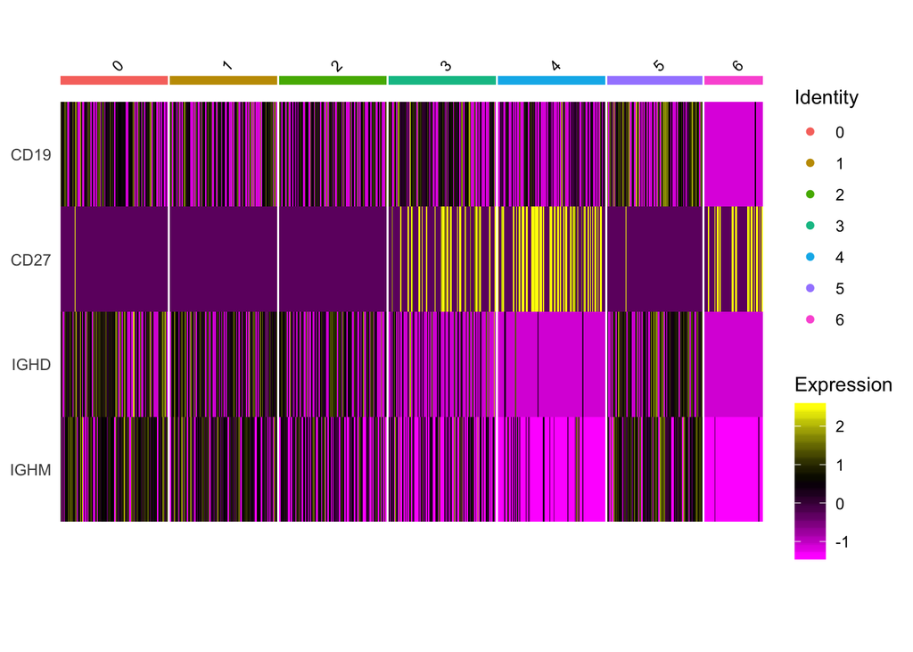

```r
DoHeatmap(subset(cd19, downsample = 100), features = features, size = 3)
```

```r
#FindMarkers(cd19, ident.1 = 3, ident.2 = c(0,1,2,4:6), min.pct = 0.25)
```

# Manually ID subset

Using the Seurat tutorial allows me to locate cells expressing markers of interest but not to indentify cells expressing a combination of markers. Use a manual strategy to obtain the barcode of cells expressing the combination of markers corresponding to MZ cells.

- https://stackoverflow.com/questions/29511215/convert-row-names-into-first-column
- https://stackoverflow.com/questions/6778908/transpose-a-data-frame
- https://satijalab.org/seurat/v3.1/pbmc3k_tutorial.html
- What does data in a count matrix look like?

```r
# https://satijalab.org/seurat/v3.1/pbmc3k_tutorial.html
# What does data in a count matrix look like?
# https://github.com/satijalab/seurat/wiki/Seurat#data-access
# https://www.rdocumentation.org/packages/Matrix/versions/1.2-18/topics/dgTMatrix-class
# https://stackoverflow.com/questions/6778908/transpose-a-data-frame

# try to ID cells coexpressing markers working directly with the sparse matrix
features <- c("CD19", "CD27", "IGHD", "IGHM")
cd19_filtered <- cd19.data[features,]

cd19_filtered_df <- dplyr::as_tibble(cd19_filtered)

# cells are collumns feature as row. Need to transpose the data frame with data table

# transpose
t_cd19_filtered_df <- data.table::transpose(cd19_filtered_df)

# get row and colnames in order
#colnames(t_cd19_filtered_df) <- rownames(cd19_filtered_df)
colnames(t_cd19_filtered_df) <- features
rownames(t_cd19_filtered_df) <- colnames(cd19_filtered_df)

#View(t_cd19_filtered_df)

# pb with this approach I don't keep the column name so I need to transform the barcode as a column
# https://stackoverflow.com/questions/29511215/convert-row-names-into-first-column

t_cd19_filtered_df <- tibble::rownames_to_column(t_cd19_filtered_df, "Barcode")
#View(t_cd19_filtered_df)

MZ <- t_cd19_filtered_df %>%
    filter( (CD27 > 0) & (IGHD > 0 & IGHM > 0) )
#View(MZ_2)
nrow(MZ)
```

```
## [1] 75
```

```r
#MZ$Barcode

MZ_barcode <- t_cd19_filtered_df %>%
    filter( (CD27 > 0) & (IGHD > 0 & IGHM > 0) ) %>%
    mutate( Barcode2 = paste0(Barcode, "-1")) %>%
    select(Barcode2)

#View(MZ_barcode)
#write.csv(MZ_barcode, "Output/Extracted_MZ_IGHM/MZ_barcodes.csv")
```

```r
knitr::kable(head(MZ_barcode))
```

| Barcode2 |
| --- |
| AAACGGGTCACGATGT-1 |
| ACACTGAAGATCGGGT-1 |
| ACACTGAGTTATTCTC-1 |
| ACGAGGATCCCTTGCA-1 |
| ACGCCGACAGGACCCT-1 |
| ACTGTCCTCAGTGCAT-1 |

The barcodes can be used to extract IgH sequences for each subsets and process with clonal analysis.